# Module 3 Lecture - Probability Topics

Introduction to Statistical Methods

Quinton Quagliano, M.S., C.S.P

Department of Educational Psychology

# 1 Overview and Introduction

Agenda

1 Overview and Introduction

2 Terminology

3 Independent and Mutually Exclusive Events

4 Contingency Tables

5 Tree and Venn Diagrams

6 Conclusion

## 1.1 Learning Objectives

- Understand and use the terminology of probability.
- Determine whether two events are mutually exclusive and whether two events are independent.
- Calculate probabilities using the Addition Rules and Multiplication Rules.
- Construct and interpret Contingency Tables.
- Construct and interpret Venn and Tree Diagrams.
- Begin to appreciate how probability connects back to the broader idea of statistics
- Understand the emphasis of chance and probability, not certainty, in statistics

## 1.2 Introduction

- Most decisions we make are a (hopefully educated) guess.
  - E.g., Should I wear my boots if it might rain today?, What are the chances that my class will respond well to this activity?
  - Chance and probability is intuitive, and, if we introspect closely, it plays a role in pretty much everything we do
- **Discuss: Try coming up with more examples of weighing probability in your own life**
- **Probability** is a core part of statistics, and our inferential results are often phrases in recognizing that level of uncertainty
  - This is why you never really hear good scientists say we have definitively “proved” something - there’s always room left for uncertainty
  - In science, we are trying to demonstrate something beyond a reasonable doubt
- There is a lot of vocabulary (and math) surrounding probability
  - You could take an entire semester long class just talking about probability and the philosophy/math of it!
  - We’ll try to stay centered on exploring it as relevant to statistics, though this module may initially feel very removed from statistics
- **Important: Even though we won't be 'in the weeds' as much with probability calculations later on, it will remain an important background subject!**

# 2 Terminology

Agenda

1 Overview and Introduction

2 Terminology

3 Independent and Mutually Exclusive Events

4 Contingency Tables

5 Tree and Venn Diagrams

6 Conclusion

## 2.1 Introduction

- Like with the last module, practice makes perfect
  - Please use the various exercises in the book and visit GA and/or professor office hours!
  - This is also a great time to embrace flashcards, if that historically works well for you

## 2.2 Rapid Fire Vocabulary

- In the context of probability, an **experiment** is some tightly controlled and monitored action - similar to how we use the term in research design
  - If the experiment is not **pre-determined**, that is, it’s outcome is not guaranteed, then there is some amount of **chance**
  - So if we call something a **chance experiment**, its some controlled action that we are not sure of the outcome
  - Classic example is a coin flip
- **Question: Example of how probability are intuitive (to an extent) - what is the chance that I flip a coin and it lands on 'tails'**
- A) 25\%
- B) 75\%
- C) 50\%
- D) 0\%
- The final result of the experiment is called an **outcome**
  - The possibilities of all the different outcomes is called the **sample space** (notation = $S$)
  - Sample space is represented through **list notation**, or in a tree or venn diagram; more example of these later
  - Coin flip with possible heads ($H$)/tails ($T$) outcomes list notation example = $S = \{H,T\}$
  - 6-sided dice roll in list notation: $S = \{1, 2, 3, 4, 5, 6\}$
- An **event** is some combination of outcome(s)
  - Important to know that it could just be one outcome or more than on described outcome
  - Events will be defined as upper case letters like $A$, $B$, $C$, etc.
  - Example: Event A would be a six-sided die landing on a number 1 through 3
- The **probability** of a certain event occurring is described as the **long-term relative frequency** of said event
- **Discuss: Review: from module 2, try to describe in your own words what relative frequency is?**
- More on long-term relative frequency
  - What that means is that the probability describes how often a certain event would occur if the experiment were to be completed an infinite number of times; this hinges on the **law of large numbers**
  - The probability of a certain event happening will be written as $P(x)$, where $x$ is whatever event is being looked at
    - $P(x)$ will always be $\geq 0$ and $\leq 1$
  - When $P(x)$ of all possible outcomes are equal to one another, we would say that this experiment is **equally-likely/fair**
- **Discuss: Review: from module 2, we've talked about the law of large numbers before. Try explaining in your own words how it relates to sample statistics and population parameters**
- Example of coin toss, where outcome $H$ is the likelihood of flipping with an outcome of head on a single toss, and outcome $T$ is the likelihood of tails
  - If $P(H) = 0.50$, i.e., a 50% chance to land on heads
  - If $P(T) = 0.50$, i.e., a 50% chance to land on tails
  - If $P(H) = P(T)$, i.e., equally likely experiment
- **Discuss: Try writing out the same set of bullets that I just did, but with a six-sided equally likely die instead. We will calculate it out in a second, but try to just do this intuitively now.**

## 2.3 Calculating Probability

- In the scenario that we aim to calculate the probability of a single event in an equally likely sample space:
- Steps to calculate:
  1. Determine all possible outcomes from the experiment and list them out, counting the number of possible outcomes
  2. Define a specific event
  3. Assess how many outcomes match that event
  4. Divide the number of outcomes that match the event by the total number of outcomes; $P(x) = Matching / Total$
- Do a coin toss of a dime and nickel
  1. 4 outcomes in the sample space: $\{HH, TH, HT, TT\}$ where
  - $H$ heads on a coin
  - $T$ tails on a coin
  - In writing this would be: both coins land on heads, dime lands tail and nickel lands heads, dime lands heads and nickel lands tails, both coins land on tails
  1. Event $A$ of getting at only one heads; could also be written as $A: n_H = 1$
  2. Two outcomes in the sample space match this criteria: $/{TH, HT/}$
  3. Thus the probability of event $A$ is calculated as $P(A) = 2 / 4 = 0.50$
- **Discuss: Trying doing the same full calculation process now, but now for a 6-sided equally likely die.**
- Practically, many events are not perfectly fair / equal - coin flips are affected by the person doing them, air resistance, etc.
  - This will be called **unfair/biased**

## 2.4 OR Events

- An **OR event** is when an event is written in such a manner that an outcome could match event $A$ or $B$
  - This would be written as $A \cup B$ (that symbol is called a cup)
  - Applying the above, we would have a two step process of determining the outcome match $A$ OR $B$ and would give the probability as $P(A \cup B)$
  - Practical example: What is the chance that a student has a GPA above 3.00 OR an SAT score above 1400.
- To list the possible outcomes, we find the **set union** of the two sets of outcomes that match the respective events, example:
  - If $A$ matches $\{1, 2\}$ and
  - If $B$ matches $\{2, 3, 4\}$ then
  - $A \cup B$ matches $\{1, 2, 3, 4\}$
  - Then we proceed by using $A \cup B$ matches in step 4 of Calculating Probability

## 2.5 AND Events

- An **AND event** is when an event is written in a manner that an outcome must match event $A$ and $B$
  - This would be written as $A \cap B$ (this symbol is a cap, like a hat)
  - Thus probability would be written as $P(A \cap B)$
  - Practical example: What is the chance that a student has a GPA above 3.00 AND an SAT score above 1400.
- To list the possible outcomes, we find the **set intersection** of the two sets of outcomes that match the respective events, example:
  - If $A$ matches $\{1, 2, 3\}$ and
  - If $B$ matches $\{2, 3, 4\}$ then
  - $A \cap B$ matches $\{2, 3\}$
  - Then we proceed by using $A \cap B$ matches in step 4 of Calculating Probability
- **Important: A mnemonic to remember caps and cups: cAps are for Ands**
- **Discuss: Try writing out (just in words, not notation) an example of an OR and AND event relevant to your field of interest, like I did with GPA and SAT earlier**

## 2.6 Conditionals and Complements

- **Compliments** take the inverse, or everything but the matching outcomes of an event
  - This is written at the prime of an outcome, e.g., $A'$ is the complement of $A$
  - Thus, probability of a conditional would be notated as $P(A')$
  - In such a scenario, instead of finding all the outcomes that DO match the event, we would list all the outcomes that dont match the event in step 3 of Calculating Probability
  - Example: What is the probability that a patient does NOT have an IQ below 85?
- **Conditionals** are the probability a certain event occurs given that another event has already happened
  - It is written as $P(A|B)$, which translates to probability of $A$ given $B$ (the vertical bar is sometimes called a pipe)
  - Example: If a person is determined to dislike pizza, what is the probability they will also dislike pasta?
  - This is calculated via the following formula, assuming $P(B) \neq 0$:

$$P(A|B) = \frac{A \cap B}{B}$$

- Once again, try working through the problems and solutions in your book for all of these scenarios!
- **Discuss: Consider the following prompt: 'I am calculating the probability that a person is in the 90th percentile on reading and math abilities, given that they are established to be above the 80th percentile on writing' Which of the event types that we've discuss does this prompt use: AND, OR, Compliment, Conditional**

# 3 Independent and Mutually Exclusive Events

Agenda

1 Overview and Introduction

2 Terminology

3 Independent and Mutually Exclusive Events

4 Contingency Tables

5 Tree and Venn Diagrams

6 Conclusion

## 3.1 Introduction

- We are often interested in how two possible events are potentially related or unrelated
  - We can investigate both the independence and mutually exclusivity of events to determine this
  - These are both special descriptions

## 3.2 Independence

- Two events are considered to be **independent** if they are unrelated/do not affect one another
  - On the contrary, if they are somehow related to one another, they are said to be **dependent**
- The following are the possible rules to show independence:
  - $P(A|B) = P(A)$
  - $P(B|A) = P(B)$
  - $P(A \cap B) = P(A)P(B)$ (The **Multiplication Rule**)
  - Only one of these conditions needs to be met for establishing independence
- It is safest to assume dependence of events until independence has been established
  - Sort of counter-intuitive, but useful to our assumption for inferential tests, more on that later

### Connection to Sampling Process

- Recall that in a *random* sampling scenario, there is a theoretically equal chance for each member of the population of interest to be selected
  - Effectively, random sampling is sampling that is done in an *equally likely* manner
  - Example: If I am sampling US military veterans (let’s say $n = 1000$), then a truly random sampling will give each of those people (outcomes) a probability of 1/1000 to be chosen
- Sampling can be done one of two ways, that impact whether sampling decisions were made independent of one another
  - **Sampling with replacement**: means the same individual could be chosen multiple times - this means the odds of being selected as a member of the population remain the same (e.g., selection of each individual is independent)
  - **Sampling without replacement**: means it is done in a manner that a person cannot be chosen multiple times, thus reducing the outcomes by one and changing the odds for each subsequent selection (e.g., selection of each individual is dependent)
  - Marble example
- **Important: Thus, our sampling is not truly 'random' unless we do it with replacement!**
- **Discuss: Consider the following prompt 'I simple random sampled 50 individuals from a larger population without replacement, does this result in a sample that should be reprsentative of the broader population?'**

## 3.3 Mutually Exclusivity

- Events are **mutually exclusive** when they cannot occur at the same time and follow the **Addition Rule**:

$$P(A \cap B) = 0.00$$

- If unsure, assume non-exclusivity until this rule is met

# 4 Contingency Tables

Agenda

1 Overview and Introduction

2 Terminology

3 Independent and Mutually Exclusive Events

4 Contingency Tables

5 Tree and Venn Diagrams

6 Conclusion

## 4.1 Introduction

- The word “contingent” means to depend on, so **contingency tables** offer a nice view for displaying probabilities in such a way to investigate dependence
- **Important: Like with descriptive statistics, using graphical and tabular displays can make it much easier to navigate complex information, make sure you use them!**

## 4.2 Example of a Contingency Table

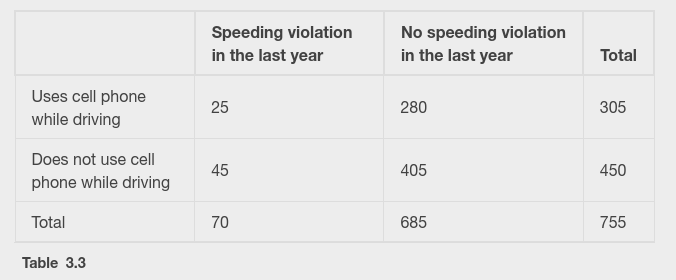

# 5 Tree and Venn Diagrams

Agenda

1 Overview and Introduction

2 Terminology

3 Independent and Mutually Exclusive Events

4 Contingency Tables

5 Tree and Venn Diagrams

6 Conclusion

## 5.1 Introduction

- Just like with how descriptive statistics have several ways to graphically present, so do probabilities!
  - Contingency tables are a great start, but we can add to them with tree diagrams and venn diagrams
- For this section, I’ll be a bit more brief only because these representations are not super practical in most applied statistics
- **Important: In scenarios with large sample spaces, the tree and venn diagrams may offer more practical representations, but realistically list notation works fine for most scenarios**

## 5.2 Tree Diagrams

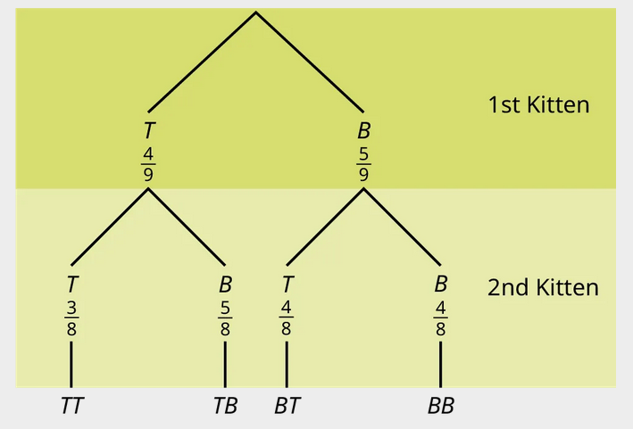

## 5.3 Venn Diagrams

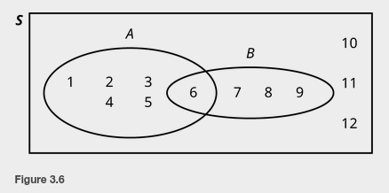

# 6 Conclusion

Agenda

1 Overview and Introduction

2 Terminology

3 Independent and Mutually Exclusive Events

4 Contingency Tables

5 Tree and Venn Diagrams

6 Conclusion

## 6.1 Recap

- Probability is a tough subject, but it is critical as a foundation topic prior to understanding inferential statistics!
- Understand that when we discuss statistical results going forward, it will always be in through the lens of probabilities and likelihood of outcomes.
- While “real” statistics won’t often involve intensive hand calculation of probabilities, you should still have a foundation appreciation of how to do it - just like we did with standard deviation.

## 6.2 Lecture Check-in

- Make sure to complete any lecture check-in tasks associated with this lecture!

[figure not shown]

Module 3 Lecture - Probability Topics || Introduction to Statistical Methods